# Kravd innlating 1

**TipWrite your full name (if individual) or names (if group work) here**

- Magnus Hansen
- John Askham
- Hanus Løwe

**TipNote**

- Preferably, work in groups of 2-4 people although individual solutions to the assignment are allowed.
- Use a RStudio-project and put the provided data files into a directory named “data” under your project-directory.
- Use this quarto document as a template for this assignment in which you load the packages: `tidyverse, knitr, readxl, moderndive, waldo`.
- Use the provided code chunks and text boxes in the template to answer the exercises. There is a setup chunk and one code chunk for each question that are labelled corresponding to each question. Where there are questions to be answered with text, use the provided text-boxes below such questions.
- For the final solution, test and review the code and text answers before handing in.
- Each student should individually hand in their tested and reviewed solution even though it was made as group-work.
- When finished, name your individual documents like: “2000.000_kravd1_5021_2026.qmd” where you correct the numbers at the start to your student id number. Hand in both your quarto- and rendered html file through the Moodle-page for this course.
- All students in a group should have contributed equally to discussing and solving the exercises.
- Feed back will be given personally to individuals or groups. All students, working individually or in groups, must be able to orally answer questions about their understanding of code- and text answers to get the assignment approved.

**TipAbout this assignment**

This assignment mainly covers what you have learned from chapters 1-5 in the Moderndive v2 textbook about the concept of reproducible research with the tidyverse tools for data visualization, data wrangling, data import and tidy data, as well as for simple linear regression. For data import, we also studied the R for Data Science 2e textbook: 7.2 Reading data from a file, that contains useful tips for data import.

````markdown
```{r}
#| label: setup
#| message: false

# load packages here
library(readxl)
library(knitr)
library(tidyverse)
library(moderndive)
library(waldo)
# set theme for plotting
# theme_set(theme_minimal())
```
````

## Exercise 1

> 1a) Read in the provided Excel files `MENS_EHF_EURO2026.xlsx` and `WOMENS_EHF_EURO2024.xlsx` with data on top scorers in the Men’s EHF European Handball Championship 2026 and Women’s EHF European Handball Championship 2024, which were downloaded from the EHF website. The data have column names (`Rank, Lastname, Firstname, Country, Matches, Shots, Goals, Efficiency`). Read the data into objects `top_men` and `top_women`, changing the types of the columns `Matches, Shots, Goals, Efficiency` to “numeric”. Also, add the columns `Sex = "Men", Year = "2026"` in `top_men`, and `Sex = "Women", Year = "2024"` in `top_women`. Finally, bind the two objects `top_men` and `top_women` by rows into object `top_scorers`. Display the final object as simple as you can (not using `kable()`).

````markdown
```{r}
#| label: 1a

# code here
top_men <- read_excel("data/MENS_EHF_EURO2026.xlsx")
top_women <- read_excel("data/WOMENS_EHF_EURO2024.xlsx")

top_men <- top_men %>%
  mutate(
    Matches = as.numeric(Matches),
    Shots = as.numeric(Shots),
    Goals = as.numeric(Goals),
    Efficiency = as.numeric(Efficiency),
    Sex = "Men",
    Year = "2026"

  )

top_women <- top_women %>%
  mutate(
    Matches = as.numeric(Matches),
    Shots = as.numeric(Shots),
    Goals = as.numeric(Goals),
    Efficiency = as.numeric(Efficiency),
    Sex = "Women",
    Year = "2024"

  )


top_scorers <- bind_rows(top_men,top_women)
top_scorers
```
````

```
# A tibble: 60 × 10
    Rank Lastname  Firstname Country Matches Shots Goals Efficiency Sex   Year
   <dbl> <chr>     <chr>     <chr>     <dbl> <dbl> <dbl>      <dbl> <chr> <chr>
 1     1 Gidsel    Mathias   DEN           9    95    68       71.6 Men   2026
 2     2 Pytlick   Simon     DEN           9    90    64       71.1 Men   2026
 3     3 Costa     Francisco POR           8    94    61       64.9 Men   2026
 4     4 Magnússon Ómar Ingi ISL           9    72    55       76.4 Men   2026
 5     5 Pedersen  August    NOR           7    62    49       79   Men   2026
 6     6 Makuc     Domen     SLO           7    74    48       64.9 Men   2026
 7     7 Imre      Bence     HUN           7    57    46       80.7 Men   2026
 8     8 Costa     Martim    POR           8    67    44       65.7 Men   2026
 9     9 Uščins    Renārs    GER           9    75    43       57.3 Men   2026
10    10 Jakobsen  Emil      DEN           9    54    40       74.1 Men   2026
# ℹ 50 more rows
```

> We are now ready to plot the data `top_scorers` using `tidyverse` tools.

> 1b) Use `ggplot()` to create a scatterplot of `Efficiency` versus `Shots` in `top_scorers`. Add a single linear regression line with a confidence band. Map both the shape and color of the data points to a combined text string containing `Sex` and `Year` to create a single legend with two lines describing the competition (“Men 2026” and “Women 2024”). Remove the legend title. Use an appropriate title for the plot, e.g., “Figure 1b: Top Scorers EHF Euro – describe plot”, where “Figure 1b” refers to the plot for this question and “describe plot” is a short description of the plot.

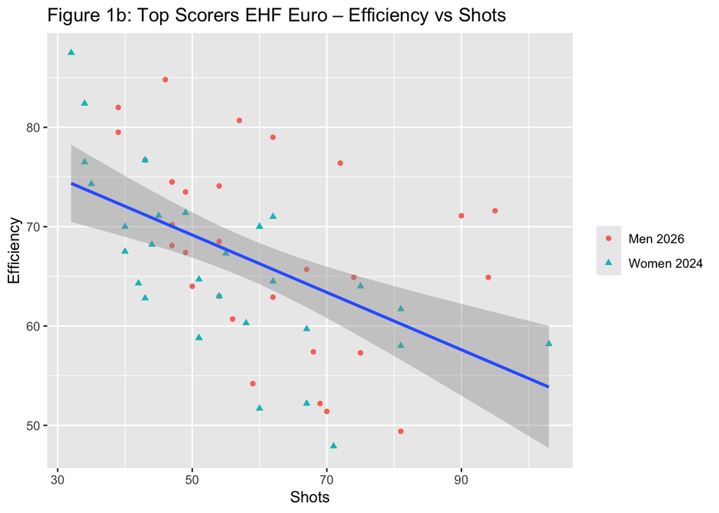

````markdown
```{r}
#| label: 1b

# code here
ggplot(top_scorers, aes(x = Shots, y = Efficiency)) +
  geom_point(aes(color = paste(Sex, Year), shape = paste(Sex, Year))) +
  geom_smooth(method = "lm") +
  labs(
    x = "Shots",
    y = "Efficiency",
    title = "Figure 1b: Top Scorers EHF Euro – Efficiency vs Shots",
    color = NULL,
    shape = NULL
  )
```
````

> 1c) Use `ggplot()` to create a histogram of `Goals/Matches`, faceted by a combined text string containing `Sex` and `Year` for the competition. Add `scale_x_continuous()` and `scale_y_continuous()` with appropriate breaks. Label the y-axis “Count of Top Scorers”. Use an appropriate title for the plot, e.g., “Figure 1c: Top Scorers EHF Euro – describe plot”.

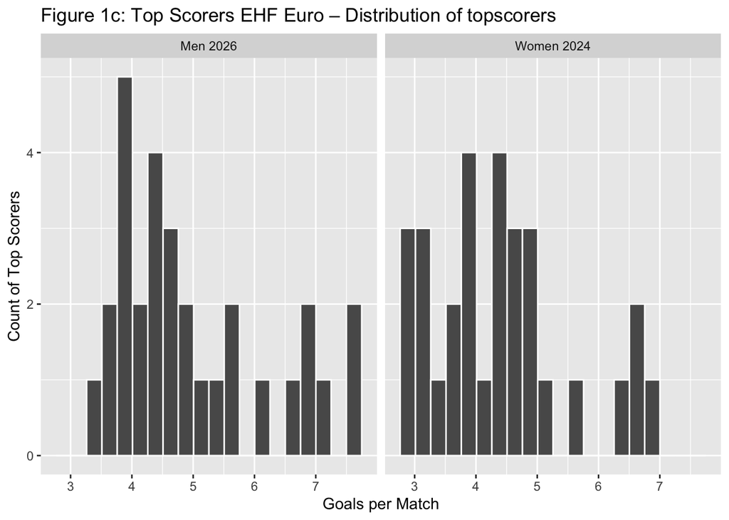

````markdown
```{r}
#| label: 1c

# code here
ggplot(data = top_scorers, mapping = aes(x = Goals/Matches)) +
  geom_histogram(color = "white", bins = 20) +
  facet_wrap(~ paste(Sex, Year)) +
  scale_x_continuous(breaks = seq(0, 10, by = 1)) +
  scale_y_continuous(breaks = seq(0, 10, by = 2)) +
labs(
    x = "Goals per Match",
    y = "Count of Top Scorers",
    title = "Figure 1c: Top Scorers EHF Euro – Distribution of topscorers"
)
```
````

> In the following questions and exercises, always use an appropriate title for your plots, labeled similarly to your first two plots.

> 1d) Use `ggplot()` to create a boxplot of `Goals/Matches` as the y-variable versus a combined text string of `Sex` and `Year` as the x-variable. Label the x-axis “Competition”.

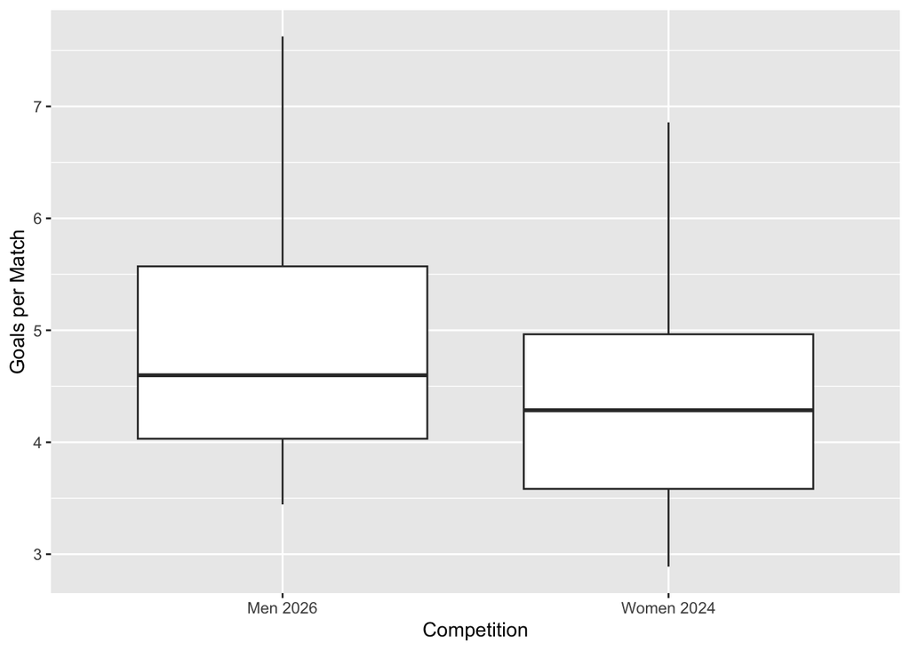

````markdown
```{r}
#| label: 1d

# code here
ggplot(data = top_scorers, mapping = aes(x = paste(Sex, Year), y = Goals/Matches)) +
  geom_boxplot() +
  labs(
    x = "Competition",
    y = "Goals per Match"
)
```
````

> 1e) Similarly, use `ggplot()` to create a boxplot of `Efficiency` as the y-variable versus a combined text string of `Sex` and `Year` as the x-variable. Label the x-axis “Competition”.

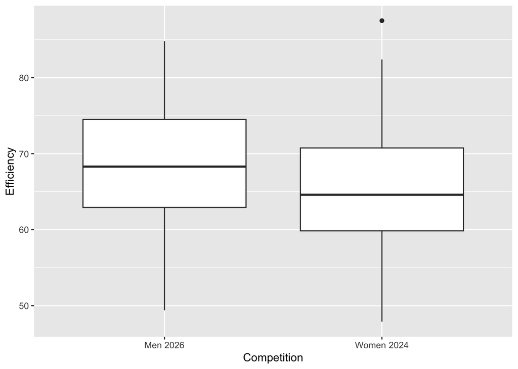

````markdown
```{r}
#| label: 1e

# code here
ggplot(data = top_scorers, mapping = aes(x = paste(Sex, Year), y = Efficiency)) +
  geom_boxplot() +
  labs(
    x = "Competition",
    y = "Efficiency"
)
```
````

> 1f) Plots are visually appealing, but sometimes a numerical summary of the data is also needed. In a pipe statement, pipe `top_scorers` into `mutate()` to add `Goals/Match = Goals/Matches`. Then, grouped by the two variables `Sex` and `Year`, use `reframe()` and `tidy_summary()` to create a numerical summary of `Matches, Shots, Goals, Goals/Match, Efficiency`. Exclude the columns `group` and `type` from the summary, `arrange()` the table by `column`, and save the output in `table_1f` (tip: it is a tibble 10 × 11). Display it using `kable()` with an appropriate caption, e.g., “Table 1f: Top Scorers EHF Euro – Summary Statistics”.

````markdown
```{r}
#| label: 1f

# code here
table_1f <- top_scorers %>%
  mutate("Goals/Match" = Goals/Matches) %>%
  group_by(Sex,Year) %>%
  reframe(tidy_summary(pick(Matches,Shots,Goals, "Goals/Match", Efficiency))) %>%
  select(-group,-type) %>%
  arrange(column)

kable(table_1f,
      caption ="Table 1f: Top Scorers EHF Euro – Summary Statistics")
```
````

Table 1f: Top Scorers EHF Euro – Summary Statistics

| Sex | Year | column | n | min | Q1 | mean | median | Q3 | max | sd |
| --- | --- | --- | --- | --- | --- | --- | --- | --- | --- | --- |
| Men | 2026 | Efficiency | 30 | 49.400000 | 62.925000 | 68.020000 | 68.300000 | 74.500000 | 84.800000 | 9.5633424 |
| Women | 2024 | Efficiency | 30 | 47.900000 | 59.850000 | 65.816667 | 64.600000 | 70.750000 | 87.500000 | 8.7741424 |
| Men | 2026 | Goals | 30 | 31.000000 | 33.250000 | 40.533333 | 36.500000 | 43.750000 | 68.000000 | 9.9818226 |
| Women | 2024 | Goals | 30 | 26.000000 | 28.500000 | 35.300000 | 33.500000 | 40.000000 | 60.000000 | 8.3134706 |
| Men | 2026 | Goals/Match | 30 | 3.444444 | 4.031250 | 5.007738 | 4.598214 | 5.571429 | 7.625000 | 1.2557894 |
| Women | 2024 | Goals/Match | 30 | 2.888889 | 3.583333 | 4.414616 | 4.285714 | 4.964286 | 6.857143 | 1.1379610 |
| Men | 2026 | Matches | 30 | 7.000000 | 7.000000 | 8.166667 | 8.000000 | 9.000000 | 9.000000 | 0.8742813 |
| Women | 2024 | Matches | 30 | 7.000000 | 7.000000 | 8.100000 | 8.000000 | 9.000000 | 9.000000 | 0.9228890 |
| Men | 2026 | Shots | 30 | 39.000000 | 47.500000 | 60.533333 | 56.500000 | 69.750000 | 95.000000 | 15.6463796 |
| Women | 2024 | Shots | 30 | 32.000000 | 43.000000 | 55.000000 | 52.500000 | 62.000000 | 103.000000 | 16.4064748 |

> How do the boxplots in 1d) and 1e) compare with the table in 1f)?

**TipText answer to 1f**

Write your answer here. The boxplots in 1d) and 1e) match well with the table in 1f. The values for min, Q1, median, Q3, and max from the summary statistics are very similar to what is illustrated in the boxplots where men 2026 have higher values in efficiency and goal per match than women 2024.

## Exercise 2

> 2a) Modify your plot code from 1b). Add two new regression lines - one for each `Sex` - instead of the single regression line you created in 1b). Do not use confidence bands for the regression lines. Use a similar single legend as you made in 1b). However, use `scale_color_manual()` to set the color “black” for the regression line and for the data points for “Men 2026”, and similarly set the color “red” for “Women 2024”.

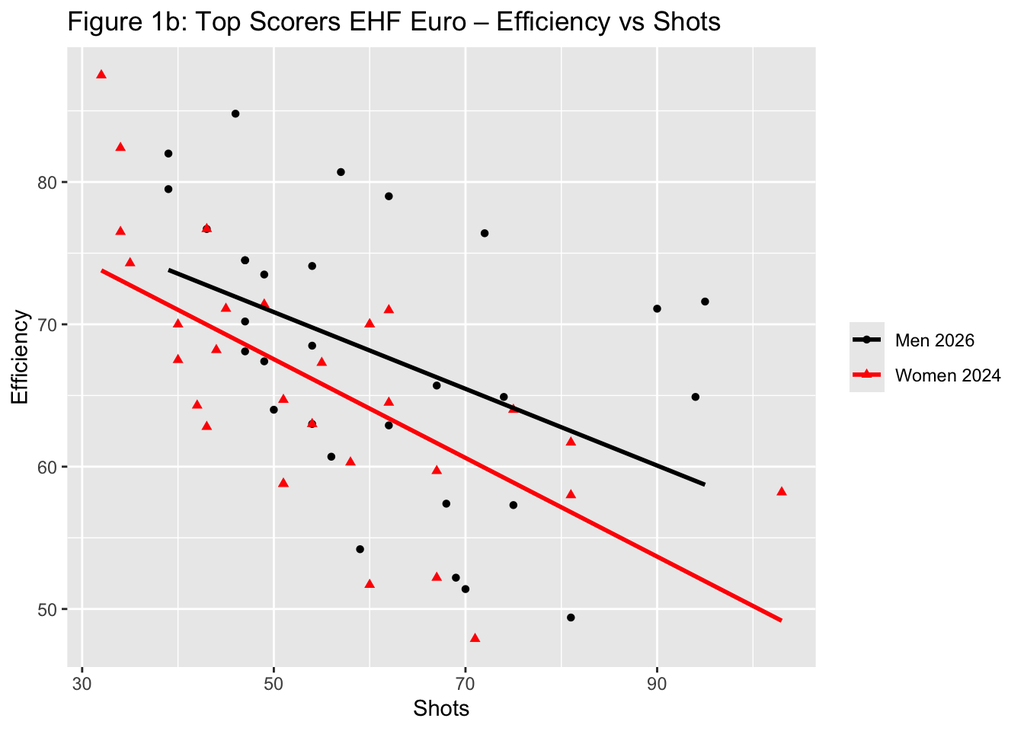

````markdown
```{r}
#| label: 2a

# code here
ggplot(top_scorers, aes(x = Shots, y = Efficiency, color = Sex)) +
  geom_point(aes(color = paste(Sex, Year), shape = paste(Sex, Year))) +
  geom_smooth(aes(color = paste(Sex, Year)), method = "lm", se = FALSE) +
  scale_color_manual(values = c("Men 2026" = "black", "Women 2024" = "red")) +
  labs(
    x = "Shots",
    y = "Efficiency",
    title = "Figure 1b: Top Scorers EHF Euro – Efficiency vs Shots",
    color = NULL,
    shape = NULL
  )
```
````

> 2b) Modify (simplify) your plot from 2a) into a facet plot. Here, you facet the plot by a combined text string containing `Sex` and `Year` to get 30 data points and one regression line in each facet. Do not map the shape or color of the data points. Therefore, you do not get colored points, or any legend. Colored points and a legend are not needed here, since the facets are described by the faceting variable (combined text string) shown by default. Use the default color for the regression lines and plot them with confidence bands.

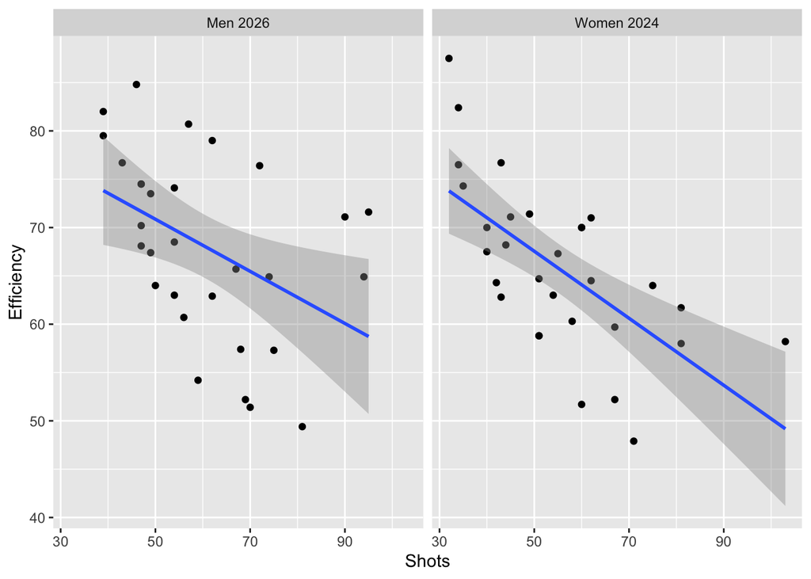

````markdown
```{r}
#| label: 2b

# code here
ggplot(top_scorers, aes(x = Shots, y = Efficiency)) +
  geom_point() +
  geom_smooth(method = "lm") +
  facet_wrap(~ paste(Sex, Year))
```
````

> 2c) In the following, you will explore a linear regression model of the data in `top_scorers`, assuming that the same linear trend exists between `Efficiency` and `Shots` regardless of `Sex`. Therefore, we do not distinguish between men and women in the linear regression model.
- In Figure 2c, modify your code from 2b) to create a single scatterplot of `Efficiency` versus `Shots` in `top_scorers` with only one regression line. Still, do not map the shape or color of the data points.

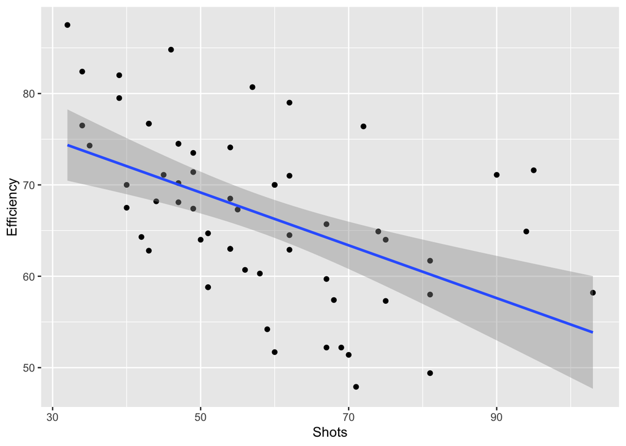

````markdown
```{r}
#| label: 2c.plot

# code here
ggplot(top_scorers, aes(x = Shots, y = Efficiency)) +
  geom_point() +
  geom_smooth(method = "lm")
```
````

- Create a model object `lm_spec` specifying a linear model of `Goals ~ Shots` with data `top_scorers`, and output the model summary using `summary(lm_spec)`.

````markdown
```{r}
#| label: 2c.model

# code here
lm_spec <- lm(Goals ~ Shots, data = top_scorers)
summary(lm_spec)
```
````

```
Call:
lm(formula = Goals ~ Shots, data = top_scorers)

Residuals:
     Min       1Q   Median       3Q      Max
-10.6646  -2.7921   0.0636   2.6132  11.0972

Coefficients:
            Estimate Std. Error t value Pr(>|t|)
(Intercept)  8.46011    2.29771   3.682  0.00051 ***
Shots        0.50992    0.03833  13.303  < 2e-16 ***
---
Signif. codes:  0 '***' 0.001 '**' 0.01 '*' 0.05 '.' 0.1 ' ' 1

Residual standard error: 4.751 on 58 degrees of freedom
Multiple R-squared:  0.7532,    Adjusted R-squared:  0.7489
F-statistic:   177 on 1 and 58 DF,  p-value: < 2.2e-16
```

- The “Residuals:” in the summary output can be used as a quick check of the distribution assumption. Does the “Residuals:” section in this case indicate any problems? Explain your reasoning.

**TipText answer to 2c)**

No, the residuals are very symmetric. The median is close to 0, and the min, 1Q, 3Q, and Max are symmetric.

> 2d) Create an `lm_regr` object to contain predictions and residuals for the model `lm_spec` and display the object `lm_regr`.

````markdown
```{r}
#| label: 2d
lm_regr <- get_regression_points(lm_spec)
lm_regr
# code here
```
````

```
# A tibble: 60 × 5
      ID Goals Shots Goals_hat residual
   <int> <dbl> <dbl>     <dbl>    <dbl>
 1     1    68    95      56.9    11.1
 2     2    64    90      54.4     9.65
 3     3    61    94      56.4     4.61
 4     4    55    72      45.2     9.82
 5     5    49    62      40.1     8.93
 6     6    48    74      46.2     1.81
 7     7    46    57      37.5     8.47
 8     8    44    67      42.6     1.38
 9     9    43    75      46.7    -3.70
10    10    40    54      36.0     4.00
# ℹ 50 more rows
```

> 2e) Use `ggplot()` to create three plots from the data in `lm_regr`:
- In Figure 2e.1, create a scatterplot of `x = Shots` and `y = residual` to produce a residuals plot.

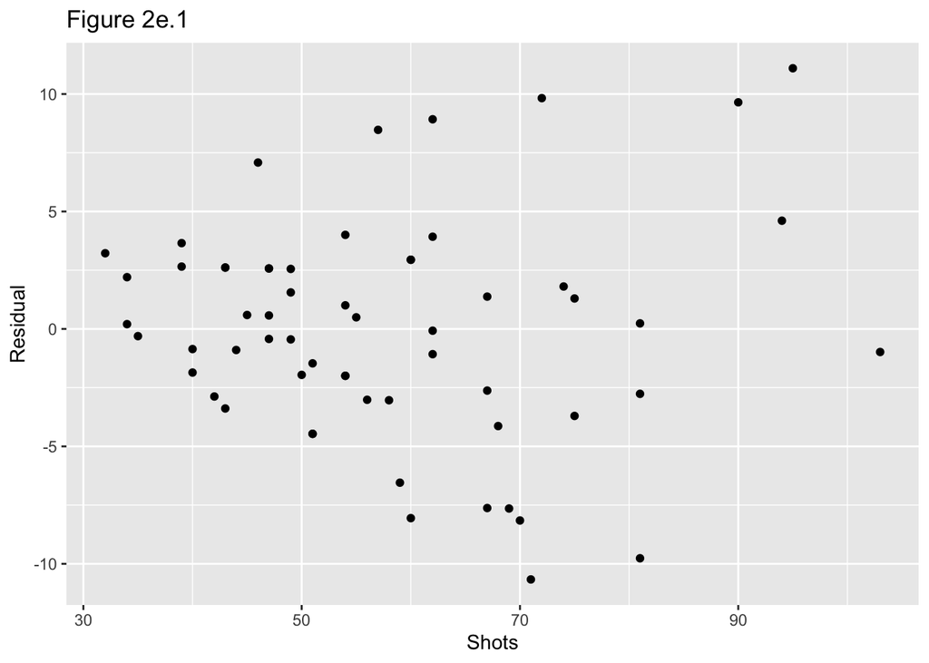

````markdown
```{r}
#| label: 2e.1

# code here
ggplot(lm_regr, aes(x = Shots, y = residual)) +
  geom_point() +
  labs(x = "Shots",
       y = "Residual",
       title = "Figure 2e.1")
```
````

- In Figure 2e.2, create a boxplot of `y = residual` to produce a residuals boxplot.

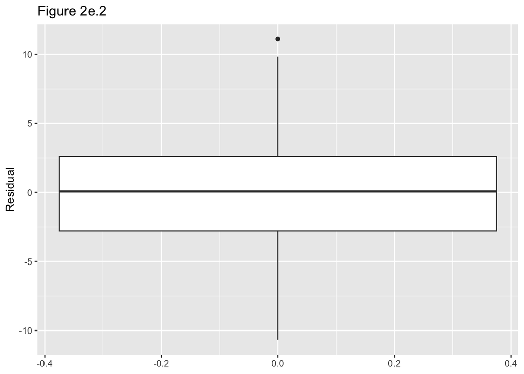

````markdown
```{r}
#| label: 2e.2

# code here
ggplot(data = lm_regr, aes(y = residual)) +
  geom_boxplot() +
  labs(y = "Residual",
       title = "Figure 2e.2")
```
````

- In Figure 2e.3, create a QQ-plot with `sample = residual`.

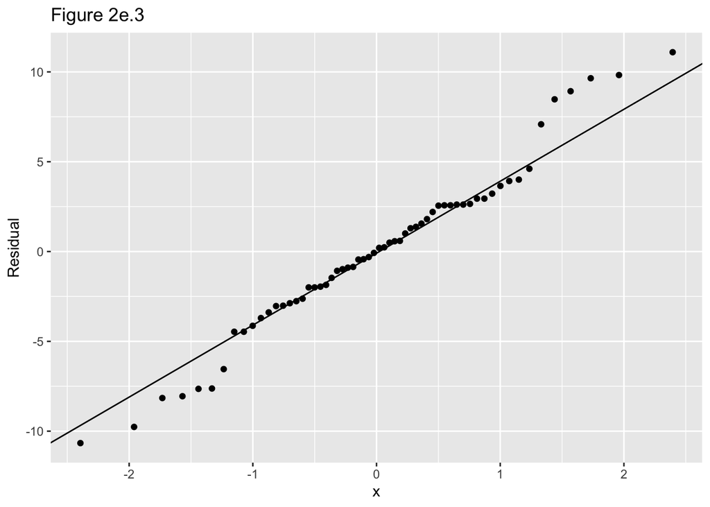

````markdown
```{r}
#| label: 2e.3

# code here
ggplot(lm_regr, aes(sample = residual)) +
  geom_qq() +
  geom_qq_line() +
  labs(y = "Residual",
     title = "Figure 2e.3")
```
````

> 2f) From your three plots in 2e), try to make your best estimate of how well the assumptions for using linear regression are fulfilled in our analysis of the model `lm_spec`.

**TipText answer to 2f**

The assumptions using learn regression are well fulfilled in the analysis of the model “lm_spec”. This is demonstrated most clearly in figure 2e.2 where the box in the boxplot is symmetrically placed around where the residual axis equals 0. This is further shown in 2e.3 where most of the points fall on the line, and the points in 2e.1 are also decently symmetrically placed.

## Exercise 3

> 3a) Use `ggplot()` and the data in `top_scorers` to create a density plot of the variable `Efficiency`.

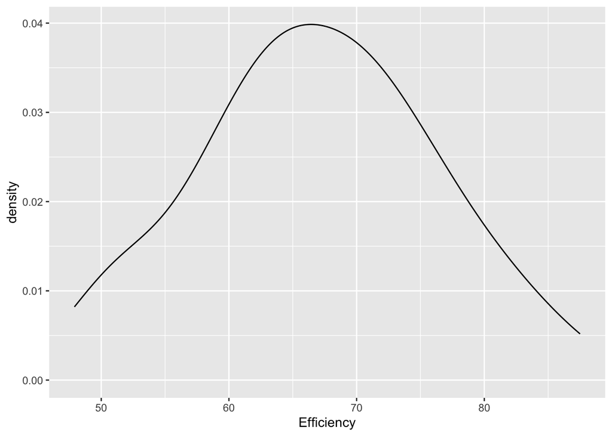

````markdown
```{r}
#| label: 3a

# code here
ggplot(top_scorers, aes(x = Efficiency)) +
  geom_density()
```
````

> 3b) Use `ggplot()` and the data in `top_scorers` to create a histogram of the variable `Efficiency`. After displaying the default histogram, adjust the bins by selecting an appropriate number of bins, or by setting an appropriate binwidth (whichever you think works best).

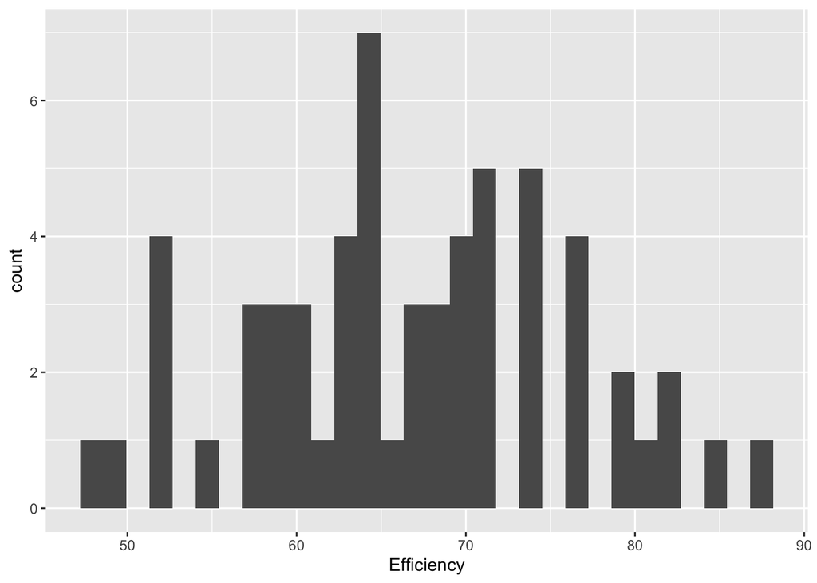

````markdown
```{r}
#| label: 3b

# code here
ggplot(top_scorers, aes(x = Efficiency)) +
  geom_histogram(bins = 30)
```
````

> 3c) Use `ggplot()` and the data in `top_scorers` to overlay a density plot on the histogram of the variable `Efficiency` (tip: this can be a bit tricky to plot. Check the documentation or online resources to see how to make the bars of the histogram density-based before overlaying the density curve. Finally, adjust the bins or bin width of the density-based histogram to get the density curve to best fit the tops of the histogram bars).

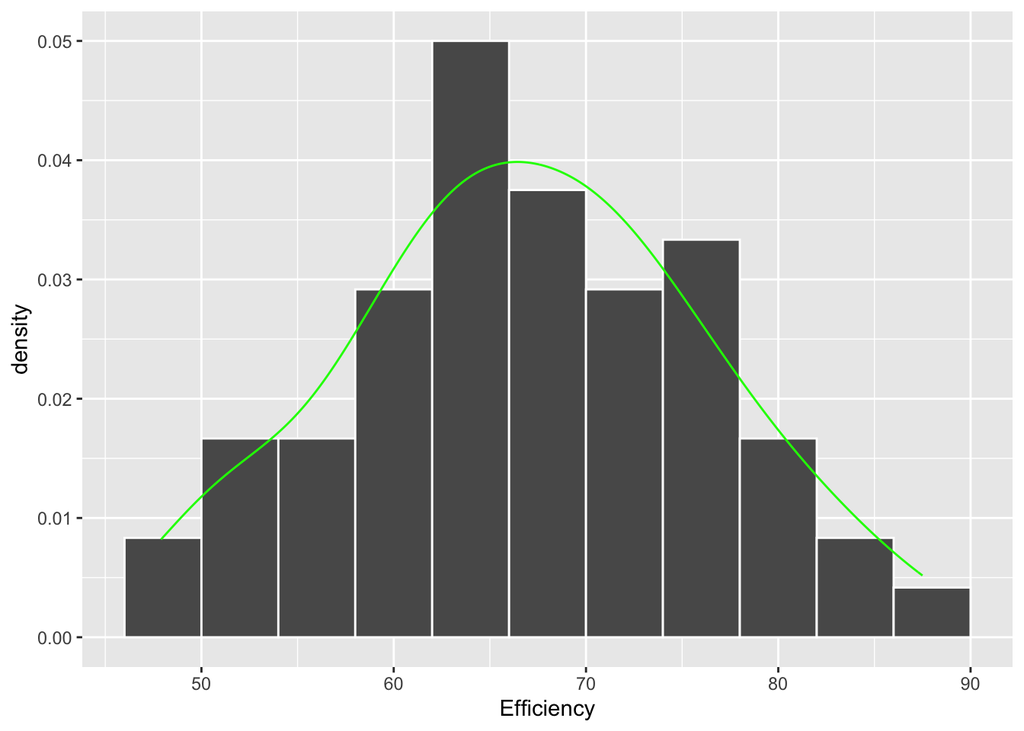

````markdown
```{r}
#| label: 3c

# code here
ggplot(top_scorers, aes(x = Efficiency)) +
  geom_histogram(aes(y = after_stat(density)), color = "white", binwidth = 4) +
  geom_density(color = "green")
```
````

> 3d) Use `ggplot()` and the data in `top_scorers` to create a density plot of the variable `Efficiency`, faceted by a combined text string containing `Sex` and `Year`, displayed with the two facets in a single column (one facet above the other).

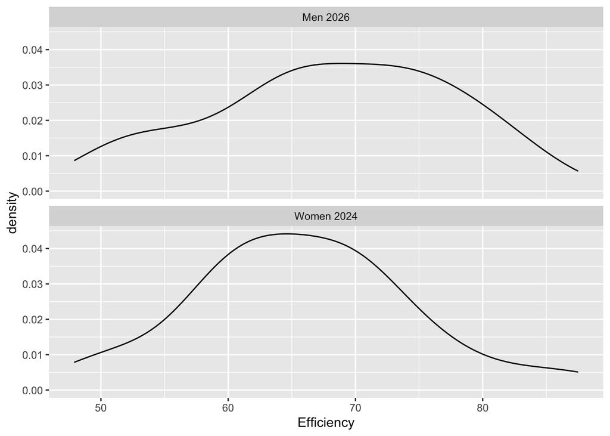

````markdown
```{r}
#| label: 3d

# code here
ggplot(top_scorers, aes(x = Efficiency)) +
  geom_density() +
  facet_wrap(~ paste(Sex, Year), ncol = 1)
```
````

> 3e) Use `ggplot()` and the data in `top_scorers` to create a histogram of the variable `Efficiency`, faceted by a combined text string containing `Sex` and `Year`, displayed with the two facets in a single column (one facet above the other). After displaying the default histogram, adjust the bins by selecting an appropriate number of bins, or by setting an appropriate binwidth (whichever you think works best).

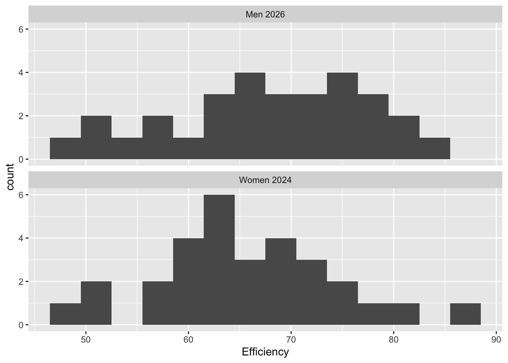

````markdown
```{r}
#| label: 3e

# code here
ggplot(top_scorers, aes(x = Efficiency)) +
  geom_histogram(binwidth = 3) +
  facet_wrap(~ paste(Sex, Year), ncol = 1)
```
````

> 3f) Use `ggplot()` and the data in `top_scorers` to overlay a density plot on the faceted histogram of the variable `Efficiency` in 3e). Adjust the bins or binwidth of the density-based histogram to get the density curve to best fit the tops of the histogram bars.

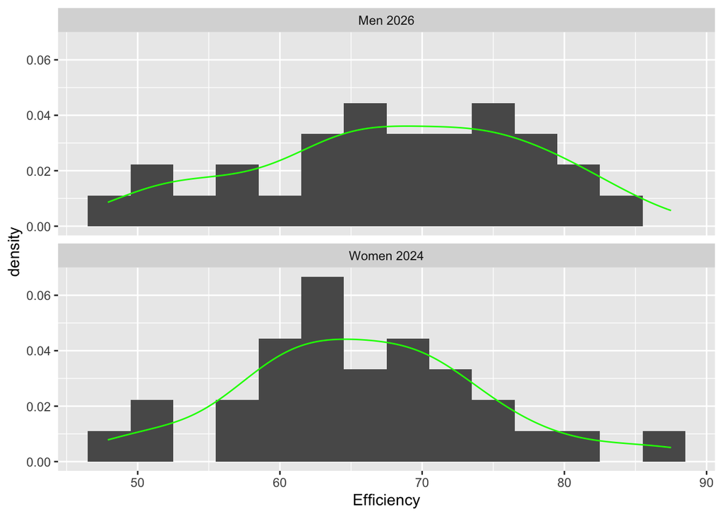

````markdown
```{r}
#| label: 3f

# code here
ggplot(top_scorers, aes(x = Efficiency)) +
  geom_histogram(aes(y = after_stat(density)), binwidth = 3) +
  facet_wrap(~ paste(Sex, Year), ncol = 1) +
  geom_density(color = "green")
```
````

## Exercise 4

> 4a) Read the provided Excel file “Folkatal_1985_2025.xlsx” into the object `folkatal`, skipping the metadata line. Display the object as simply as possible (do not use `kable()`).

````markdown
```{r}
#| label: 4a

# code here
folkatal <- read_excel("data/Folkatal_1985_2025.xlsx", skip = 1)

folkatal
```
````

```
# A tibble: 202 × 43
   Kyn     Aldur `1985` `1986` `1987` `1988` `1989` `1990` `1991` `1992` `1993`
   <chr>   <chr> <chr>  <chr>  <chr>  <chr>   <dbl> <chr>  <chr>  <chr>  <chr>
 1 Kvinnur 0 ár  336    357    388    395       429 436    445    438    388
 2 <NA>    1 ár  295    338    349    395       390 426    424    432    427
 3 <NA>    2 ár  357    290    336    356       398 390    418    411    434
 4 <NA>    3 ár  381    356    289    336       361 386    384    415    401
 5 <NA>    4 ár  366    384    361    286       331 353    383    378    402
 6 <NA>    5 ár  361    367    385    369       289 332    347    377    382
 7 <NA>    6 ár  381    364    366    385       368 293    324    342    369
 8 <NA>    7 ár  379    377    364    376       384 364    291    324    335
 9 <NA>    8 ár  376    377    377    361       372 374    358    288    327
10 <NA>    9 ár  367    375    376    382       367 366    368    358    287
# ℹ 192 more rows
# ℹ 32 more variables: `1994` <chr>, `1995` <chr>, `1996` <chr>, `1997` <chr>,
#   `1998` <chr>, `1999` <chr>, `2000` <chr>, `2001` <chr>, `2002` <chr>,
#   `2003` <chr>, `2004` <dbl>, `2005` <chr>, `2006` <dbl>, `2007` <dbl>,
#   `2008` <dbl>, `2009` <chr>, `2010` <chr>, `2011` <chr>, `2012` <chr>,
#   `2013` <chr>, `2014` <chr>, `2015` <chr>, `2016` <dbl>, `2017` <dbl>,
#   `2018` <chr>, `2019` <chr>, `2020` <chr>, `2021` <chr>, `2022` <dbl>, …
```

> 4b) Note that many cells in column `Kyn` are `NA`. This is because R assumes empty cells in the Excel file to be `NA` (missing values). In this case, however, these cells are empty because the data provider only fills the first cell of the column until the value changes. Therefore, these are not truly missing values and should be filled. Pipe the imported data `folkatal` into a fill function from the `tidyr` package to fill the `NA` cells of column `Kyn` with the correct values. Save your results in an updated object `folkatal` and display it.

````markdown
```{r}
#| label: 4b

# code here
folkatal <- folkatal |>
  fill(Kyn, .direction = "down")

kable(folkatal)
```
````

| Kyn | Aldur | 1985 | 1986 | 1987 | 1988 | 1989 | 1990 | 1991 | 1992 | 1993 | 1994 | 1995 | 1996 | 1997 | 1998 | 1999 | 2000 | 2001 | 2002 | 2003 | 2004 | 2005 | 2006 | 2007 | 2008 | 2009 | 2010 | 2011 | 2012 | … |
| --- | --- | --- | --- | --- | --- | --- | --- | --- | --- | --- | --- | --- | --- | --- | --- | --- | --- | --- | --- | --- | --- | --- | --- | --- | --- | --- | --- | --- | --- | --- |
| Kvinnur | 0 ár | 336 | 357 | 388 | 395 | 429 | 436 | 445 | 438 | 388 | 369 | 325 | 316 | 362 | 318 | 305 | 300 | 337 | 302 | 348 | 340 | 338 | 333 | 332 | 357 | 334 | 297 | 303 | 279 | … |
| Kvinnur | 1 ár | 295 | 338 | 349 | 395 | 390 | 426 | 424 | 432 | 427 | 370 | 338 | 311 | 327 | 363 | 322 | 315 | 316 | 348 | 302 | 352 | 348 | 348 | 341 | 331 | 366 | 317 | 291 | 297 | … |
| Kvinnur | 2 ár | 357 | 290 | 336 | 356 | 398 | 390 | 418 | 411 | 434 | 407 | 355 | 339 | 310 | 324 | 362 | 320 | 319 | 327 | 349 | 306 | 357 | 347 | 346 | 339 | 336 | 362 | 311 | 284 | … |
| Kvinnur | 3 ár | 381 | 356 | 289 | 336 | 361 | 386 | 384 | 415 | 401 | 413 | 381 | 350 | 338 | 316 | 325 | 371 | 323 | 329 | 336 | 359 | 314 | 352 | 350 | 348 | 345 | 335 | 367 | 314 | … |
| Kvinnur | 4 ár | 366 | 384 | 361 | 286 | 331 | 353 | 383 | 378 | 402 | 384 | 380 | 375 | 353 | 337 | 321 | 330 | 367 | 335 | 333 | 339 | 358 | 314 | 355 | 345 | 353 | 345 | 328 | 357 | … |
| Kvinnur | 5 ár | 361 | 367 | 385 | 369 | 289 | 332 | 347 | 377 | 382 | 389 | 368 | 372 | 384 | 364 | 340 | 323 | 340 | 370 | 337 | 339 | 346 | 353 | 313 | 348 | 343 | 352 | 341 | 328 | … |
| Kvinnur | 6 ár | 381 | 364 | 366 | 385 | 368 | 293 | 324 | 342 | 369 | 365 | 369 | 360 | 384 | 389 | 365 | 357 | 327 | 349 | 377 | 341 | 334 | 345 | 354 | 307 | 357 | 338 | 357 | 343 | … |
| Kvinnur | 7 ár | 379 | 377 | 364 | 376 | 384 | 364 | 291 | 324 | 335 | 357 | 351 | 367 | 372 | 393 | 396 | 377 | 370 | 343 | 355 | 381 | 348 | 334 | 351 | 362 | 313 | 363 | 335 | 362 | … |
| Kvinnur | 8 ár | 376 | 377 | 377 | 361 | 372 | 374 | 358 | 288 | 327 | 326 | 351 | 345 | 370 | 371 | 402 | 404 | 385 | 373 | 352 | 356 | 380 | 353 | 331 | 350 | 362 | 315 | 361 | 341 | … |
| Kvinnur | 9 ár | 367 | 375 | 376 | 382 | 367 | 366 | 368 | 358 | 287 | 311 | 318 | 346 | 346 | 378 | 368 | 411 | 407 | 391 | 377 | 357 | 353 | 377 | 350 | 329 | 347 | 367 | 310 | 362 | … |
| Kvinnur | 10 ár | 398 | 367 | 376 | 376 | 378 | 368 | 367 | 364 | 357 | 276 | 300 | 321 | 343 | 350 | 384 | 379 | 419 | 409 | 391 | 380 | 353 | 352 | 380 | 352 | 330 | 347 | 368 | 305 | … |
| Kvinnur | 11 ár | 384 | 399 | 371 | 374 | 373 | 373 | 363 | 367 | 363 | 343 | 267 | 295 | 324 | 341 | 347 | 390 | 382 | 424 | 415 | 396 | 377 | 350 | 357 | 371 | 344 | 333 | 346 | 372 | … |
| Kvinnur | 12 ár | 389 | 383 | 403 | 375 | 373 | 378 | 380 | 361 | 363 | 352 | 338 | 261 | 293 | 327 | 340 | 351 | 400 | 390 | 426 | 414 | 394 | 373 | 348 | 359 | 374 | 347 | 333 | 349 | … |
| Kvinnur | 13 ár | 405 | 387 | 387 | 406 | 376 | 375 | 367 | 377 | 357 | 356 | 342 | 331 | 265 | 294 | 330 | 346 | 358 | 402 | 397 | 426 | 416 | 392 | 377 | 342 | 359 | 382 | 348 | 332 | … |
| Kvinnur | 14 ár | 390 | 400 | 391 | 388 | 405 | 370 | 370 | 361 | 370 | 356 | 343 | 335 | 327 | 267 | 299 | 329 | 354 | 361 | 403 | 398 | 425 | 417 | 397 | 375 | 342 | 353 | 379 | 345 | … |
| Kvinnur | 15 ár | 413 | 390 | 399 | 388 | 385 | 390 | 348 | 364 | 349 | 362 | 338 | 334 | 322 | 324 | 263 | 300 | 332 | 357 | 369 | 393 | 391 | 417 | 415 | 379 | 367 | 331 | 342 | 378 | … |
| Kvinnur | 16 ár | 416 | 410 | 388 | 390 | 385 | 381 | 388 | 355 | 352 | 323 | 327 | 323 | 315 | 311 | 309 | 255 | 285 | 315 | 339 | 336 | 357 | 355 | 373 | 358 | 327 | 318 | 304 | 301 | … |
| Kvinnur | 17 ár | 440 | 399 | 402 | 382 | 388 | 377 | 362 | 379 | 332 | 315 | 289 | 324 | 313 | 314 | 322 | 317 | 254 | 297 | 326 | 339 | 347 | 381 | 369 | 404 | 393 | 370 | 364 | 329 | … |
| Kvinnur | 18 ár | 457 | 448 | 408 | 401 | 385 | 395 | 371 | 370 | 370 | 312 | 318 | 296 | 331 | 320 | 321 | 326 | 332 | 266 | 308 | 332 | 344 | 353 | 388 | 374 | 404 | 393 | 369 | 365 | … |
| Kvinnur | 19 ár | 404 | 442 | 444 | 404 | 411 | 382 | 375 | 357 | 348 | 333 | 298 | 302 | 291 | 325 | 312 | 322 | 328 | 323 | 265 | 305 | 332 | 328 | 345 | 384 | 378 | 391 | 390 | 371 | … |
| Kvinnur | 20 ár | 358 | 374 | 420 | 436 | 404 | 400 | 346 | 341 | 307 | 276 | 271 | 263 | 288 | 281 | 310 | 297 | 318 | 319 | 317 | 257 | 300 | 307 | 317 | 333 | 364 | 344 | 372 | 348 | … |
| Kvinnur | 21 ár | 333 | 337 | 368 | 394 | 422 | 386 | 352 | 310 | 287 | 242 | 222 | 240 | 247 | 276 | 250 | 278 | 266 | 294 | 297 | 293 | 224 | 252 | 266 | 296 | 299 | 303 | 288 | 310 | … |
| Kvinnur | 22 ár | 351 | 316 | 315 | 369 | 393 | 388 | 354 | 328 | 276 | 227 | 200 | 203 | 230 | 224 | 250 | 230 | 245 | 249 | 273 | 281 | 254 | 191 | 212 | 224 | 258 | 249 | 261 | 233 | … |
| Kvinnur | 23 ár | 291 | 343 | 305 | 316 | 374 | 384 | 354 | 310 | 298 | 246 | 191 | 195 | 200 | 211 | 218 | 225 | 242 | 228 | 240 | 256 | 260 | 237 | 182 | 199 | 208 | 237 | 219 | 234 | … |
| Kvinnur | 24 ár | 289 | 289 | 337 | 312 | 328 | 355 | 365 | 339 | 307 | 258 | 215 | 193 | 206 | 208 | 209 | 208 | 224 | 227 | 220 | 236 | 233 | 237 | 221 | 170 | 184 | 195 | 215 | 197 | … |
| Kvinnur | 25 ár | 336 | 299 | 296 | 346 | 324 | 324 | 335 | 348 | 329 | 269 | 230 | 210 | 208 | 210 | 226 | 219 | 207 | 224 | 221 | 219 | 232 | 228 | 220 | 216 | 177 | 188 | 189 | 198 | … |
| Kvinnur | 26 ár | 345 | 341 | 303 | 320 | 357 | 330 | 311 | 331 | 343 | 312 | 242 | 228 | 209 | 218 | 219 | 233 | 237 | 220 | 238 | 231 | 234 | 217 | 224 | 229 | 228 | 181 | 190 | 188 | … |
| Kvinnur | 27 ár | 315 | 352 | 352 | 314 | 326 | 365 | 319 | 308 | 322 | 323 | 287 | 240 | 237 | 236 | 221 | 227 | 233 | 258 | 237 | 244 | 230 | 233 | 229 | 227 | 241 | 230 | 173 | 187 | … |
| Kvinnur | 28 ár | 312 | 321 | 353 | 355 | 315 | 323 | 355 | 308 | 305 | 303 | 299 | 293 | 242 | 246 | 249 | 239 | 239 | 250 | 268 | 251 | 252 | 236 | 237 | 240 | 236 | 244 | 237 | 170 | … |
| Kvinnur | 29 ár | 315 | 316 | 324 | 361 | 358 | 307 | 310 | 352 | 303 | 296 | 290 | 304 | 308 | 255 | 268 | 258 | 250 | 258 | 256 | 283 | 257 | 262 | 244 | 244 | 247 | 243 | 250 | 242 | … |

[output cut: 172 more lines]

> 4c) Note that the column `Aldur` in `folkatal` is of type `chr` and contains numbers and text. Use a pipe and `mutate()` together with a string replacement function from `stringr` to modify the column so that it contains only the numbers. Save your results in an updated object `folkatal` and display it. Check that the type of column `Aldur` is still `chr` and do not change it here.

````markdown
```{r}
#| label: 4c

# code here

folkatal <- folkatal |>
  mutate(Aldur = str_remove(Aldur, " ár"))

tibble(folkatal)
```
````

```
# A tibble: 202 × 43
   Kyn     Aldur `1985` `1986` `1987` `1988` `1989` `1990` `1991` `1992` `1993`
   <chr>   <chr> <chr>  <chr>  <chr>  <chr>   <dbl> <chr>  <chr>  <chr>  <chr>
 1 Kvinnur 0     336    357    388    395       429 436    445    438    388
 2 Kvinnur 1     295    338    349    395       390 426    424    432    427
 3 Kvinnur 2     357    290    336    356       398 390    418    411    434
 4 Kvinnur 3     381    356    289    336       361 386    384    415    401
 5 Kvinnur 4     366    384    361    286       331 353    383    378    402
 6 Kvinnur 5     361    367    385    369       289 332    347    377    382
 7 Kvinnur 6     381    364    366    385       368 293    324    342    369
 8 Kvinnur 7     379    377    364    376       384 364    291    324    335
 9 Kvinnur 8     376    377    377    361       372 374    358    288    327
10 Kvinnur 9     367    375    376    382       367 366    368    358    287
# ℹ 192 more rows
# ℹ 32 more variables: `1994` <chr>, `1995` <chr>, `1996` <chr>, `1997` <chr>,
#   `1998` <chr>, `1999` <chr>, `2000` <chr>, `2001` <chr>, `2002` <chr>,
#   `2003` <chr>, `2004` <dbl>, `2005` <chr>, `2006` <dbl>, `2007` <dbl>,
#   `2008` <dbl>, `2009` <chr>, `2010` <chr>, `2011` <chr>, `2012` <chr>,
#   `2013` <chr>, `2014` <chr>, `2015` <chr>, `2016` <dbl>, `2017` <dbl>,
#   `2018` <chr>, `2019` <chr>, `2020` <chr>, `2021` <chr>, `2022` <dbl>, …
```

> 4d) Next, consider the many columns that contain years as column names, of both type `chr` and `dbl`. Tidy the `folkatal` object by using a pivot function from the `tidyr` package, ensuring that you get two new columns, `Ár` and `Antal`, both of type `integer`. Note the warnings: “Warning: NAs introduced by coercion”, that you will handle in the next question. Save your results in a new object `tidy_folkatal` and display it.

````markdown
```{r}
#| label: 4d

# code here
tidy_folkatal <- folkatal |>
  pivot_longer(
    cols = -c(Kyn, Aldur),
    names_to = "Ár",
    values_to = "Antal",
    values_transform = list(Antal = as.character)) |>
    mutate(
    Ár = as.integer(Ár),
    Antal = as.integer(Antal)
  )
```
````

```
Warning: There was 1 warning in `mutate()`.
ℹ In argument: `Antal = as.integer(Antal)`.
Caused by warning:
! NAs introduced by coercion
```

````markdown
```{r}
#| label: 4d

tidy_folkatal
```
````

```
# A tibble: 8,282 × 4
   Kyn     Aldur    Ár Antal
   <chr>   <chr> <int> <int>
 1 Kvinnur 0      1985   336
 2 Kvinnur 0      1986   357
 3 Kvinnur 0      1987   388
 4 Kvinnur 0      1988   395
 5 Kvinnur 0      1989   429
 6 Kvinnur 0      1990   436
 7 Kvinnur 0      1991   445
 8 Kvinnur 0      1992   438
 9 Kvinnur 0      1993   388
10 Kvinnur 0      1994   369
# ℹ 8,272 more rows
```

> 4e) Note that some cells initially contained a dash `-` used by the data provider to denote “Veruliga null (ikki rundað)”, i.e., zero values. In 4d), the cells containing a dash were automatically coerced to `NA`, which produced the warnings: “Warning: NAs introduced by coercion”. Here, however, these values should be set to zero. Therefore, use a replacement function from `tidyr` to replace all `NA` in column `Antal` with `0`. Save the result in an updated `tidy_folkatal` and display it.

````markdown
```{r}
#| label: 4e

# code here
sum(is.na(tidy_folkatal$Antal))

tidy_folkatal |>
  filter(is.na(Antal))


tidy_folkatal <- tidy_folkatal |>
  mutate(Antal = replace_na(Antal, 0))


sum(is.na(tidy_folkatal$Antal))

tidy_folkatal |>
  filter(is.na(Antal))

tidy_folkatal
```
````

```
[1] 85
# A tibble: 85 × 4
   Kyn     Aldur    Ár Antal
   <chr>   <chr> <int> <int>
 1 Kvinnur 97     1985    NA
 2 Kvinnur 98     1985    NA
 3 Kvinnur 98     1986    NA
 4 Kvinnur 98     1996    NA
 5 Kvinnur 99     1985    NA
 6 Kvinnur 99     1986    NA
 7 Kvinnur 99     1987    NA
 8 Kvinnur 99     1993    NA
 9 Kvinnur 99     1997    NA
10 Kvinnur 99     1998    NA
# ℹ 75 more rows
[1] 0
# A tibble: 0 × 4
# ℹ 4 variables: Kyn <chr>, Aldur <chr>, Ár <int>, Antal <int>
# A tibble: 8,282 × 4
   Kyn     Aldur    Ár Antal
   <chr>   <chr> <int> <int>
 1 Kvinnur 0      1985   336
 2 Kvinnur 0      1986   357
 3 Kvinnur 0      1987   388
 4 Kvinnur 0      1988   395
 5 Kvinnur 0      1989   429
 6 Kvinnur 0      1990   436
 7 Kvinnur 0      1991   445
 8 Kvinnur 0      1992   438
 9 Kvinnur 0      1993   388
10 Kvinnur 0      1994   369
# ℹ 8,272 more rows
```

> 4f1) For pedagogical reasons, we imported and transformed the data in several steps given in questions 4a)–e). However, we could have done it all in a single pipe sentence. Create one pipe sentence that combines these steps. Save the output in `folk` and display it.

````markdown
```{r}
#| label: 4f1

# code here

folk <- read_excel("data/Folkatal_1985_2025.xlsx", skip = 1) |>
  fill(Kyn, .direction = "down") |>
  mutate(Aldur = str_remove(Aldur, " ár")) |>
  pivot_longer(
    cols = -c(Kyn, Aldur),
    names_to = "Ár",
    values_to = "Antal",
    values_transform = list(Antal = as.character)
  ) |>
  mutate(
    År = as.integer(Ár),
    Antal = as.integer(Antal),
    Antal = replace_na(Antal, 0)
  )
```
```{r}
#| label: 4f1

folk
```
````

```
# A tibble: 8,282 × 5
   Kyn     Aldur Ár    Antal    År
   <chr>   <chr> <chr> <int> <int>
 1 Kvinnur 0     1985    336  1985
 2 Kvinnur 0     1986    357  1986
 3 Kvinnur 0     1987    388  1987
 4 Kvinnur 0     1988    395  1988
 5 Kvinnur 0     1989    429  1989
 6 Kvinnur 0     1990    436  1990
 7 Kvinnur 0     1991    445  1991
 8 Kvinnur 0     1992    438  1992
 9 Kvinnur 0     1993    388  1993
10 Kvinnur 0     1994    369  1994
# ℹ 8,272 more rows
```

> 4f2) Ensure that your `tidy_folkatal` and `folk` objects are exactly equal. This can be checked with `identical(x, y)` from base R, which returns`TRUE` if `x` and `y` are exactly equal or `FALSE` if not. If you get `FALSE`, use, for example `all.equal(x, y)` from base R, which returns `TRUE` if `x` and `y` are nearly equal and reports differences if not. Then, correct your code in 4f1) until `identical()` in 4f2) returns `TRUE`. A more modern alternative is to use `waldo::compare()` from the `waldo` package to compare and to report differences, if any. Then, fix your code in 4f1) until `identical()` returns `TRUE` and `waldo::compare()` reports “No differences”.

````markdown
```{r}
#| label: 4f2

# code here


identical(tidy_folkatal, folk)

all.equal(tidy_folkatal, folk)

waldo::compare(tidy_folkatal, folk)
```
````

```
[1] FALSE
[1] "Length mismatch: comparison on first 4 components"
[2] "Component \"Ár\": Modes: numeric, character"
[3] "Component \"Ár\": target is numeric, current is character"
`old` is length 4
`new` is length 5

`names(old)[2:4]`: "Aldur" "Ár" "Antal"
`names(new)[2:5]`: "Aldur" "Ár" "Antal" "År"

`old$Ár` is an integer vector (1985, 1986, 1987, 1988, 1989, ...)
`new$Ár` is a character vector ('1985', '1986', '1987', '1988', '1989', ...)

`old$År` is absent
`new$År` is an integer vector (1985, 1986, 1987, 1988, 1989, ...)
```

## Exercise 5

> In this exercise, the variables are in the Faroese language, and you can also use Faroese for the plot titles.

> 5a) Summarise `folk` grouped by `Ár` to find the total population `Fólkatal` for each year. Save the result in `arligt_folkatal` and display it.

````markdown
```{r}
#| label: 5a

# code here
arligt_folkatal <- folk %>%
  group_by(Ár) %>%
  summarise(
    Fólkatal = sum(Antal)
    )
arligt_folkatal
```
````

```
# A tibble: 41 × 2
   Ár    Fólkatal
   <chr>    <int>
 1 1985     45346
 2 1986     45677
 3 1987     46241
 4 1988     46883
 5 1989     47576
 6 1990     47771
 7 1991     47342
 8 1992     47200
 9 1993     46733
10 1994     45257
# ℹ 31 more rows
```

> 5b) Use `ggplot()` to create a linegraph of `Fólkatal` versus `Ár` in `arligt_folkatal`. Also, include the data points.

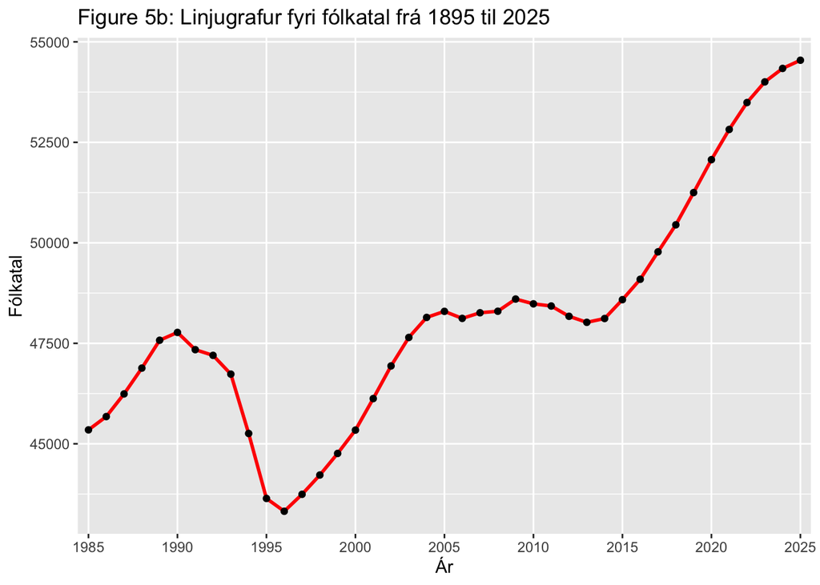

````markdown
```{r}
#| label: 5b

# code here
ggplot(arligt_folkatal, aes(Ár, Fólkatal, group = 1)) +
  geom_line(color = "red", linewidth = 1) +
  geom_point() +
  scale_x_discrete(breaks = seq(1985, 2025, by = 5)) +
  labs(title = "Figure 5b: Linjugrafur fyri fólkatal frá 1895 til 2025")
```
````

> 5c) Summarise `folk` grouped by `Ár` and `Kyn` to find the total population `Fólkatal` for each `Ár` and for each `Kyn`. Save the result in `kyn_folkatal` and display it.

````markdown
```{r}
#| label: 5c

# code here
kyn_folkatal <- folk %>%
  group_by(Ár, Kyn) %>%
  summarise(Fólkatal = sum(Antal))
```
````

[output not shown]

````markdown
```{r}
#| label: 5c

kyn_folkatal
```
````

```
# A tibble: 82 × 3
# Groups:   Ár [41]
   Ár    Kyn     Fólkatal
   <chr> <chr>      <int>
 1 1985  Kvinnur    21659
 2 1985  Menn       23687
 3 1986  Kvinnur    21812
 4 1986  Menn       23865
 5 1987  Kvinnur    22051
 6 1987  Menn       24190
 7 1988  Kvinnur    22379
 8 1988  Menn       24504
 9 1989  Kvinnur    22698
10 1989  Menn       24878
# ℹ 72 more rows
```

> 5d) Use `ggplot()` to create a linegraph of `Fólkatal` versus `Ár` in `kyn_folkatal` so that you get two curves - one for each `Kyn`. Also, include the data points for each `Kyn`. To obtain a single legend, map the color of the lines to `Kyn`, and map both the color and shape of the points to `Kyn`. Use `scale_color_manual()` to set the color for “Menn” to “blue” and for “Kvinnur” to “red”.

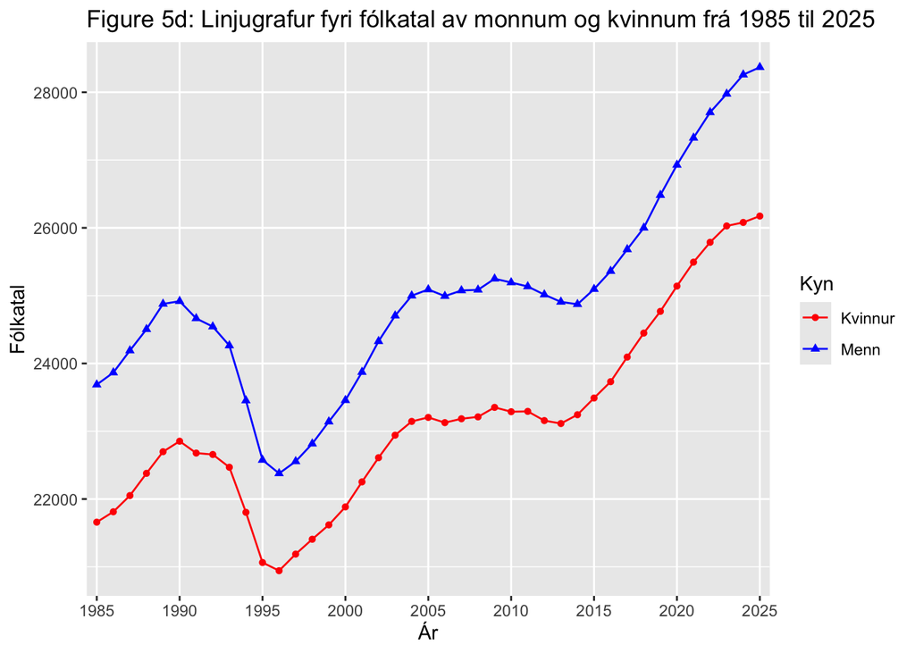

````markdown
```{r}
#| label: 5d

# code here
ggplot(kyn_folkatal, aes(Ár, Fólkatal, colour = Kyn, shape = Kyn, group = Kyn)) +
  geom_line() +
  geom_point() +
  scale_color_manual(values = c("Menn" = "blue", "Kvinnur" = "red")) +
  scale_x_discrete(breaks = seq(1985, 2025, by = 5)) +
  labs(title = "Figure 5d: Linjugrafur fyri fólkatal av monnum og kvinnum frá 1985 til 2025")
```
````

> 5e) Reuse the plot code you created in 5d). Add a similar curve of `Fólkatal` versus `Ár` from `arligt_folkatal` so that you get three curves in total - the previous two curves of `Fólkatal` per `Kyn`, described in the legend, and one additional curve of `Fólkatal` for the total population. We also want to include the third curve in the same legend. However, there is no column `Kyn` in `arligt_folkatal`. Therefore, for the curve of `Fólkatal` representing the total population, you cannot map color or shape to `Kyn`. Instead, map color and shape to the text “Bæði” to create an additional entry in the legend describing the total population. Modify `scale_color_manual()` in the plot code to define the colors for “Bæði”, “Menn”, and “Kvinnur” as “black”, “blue”, and “red”, respectively.

```
# A tibble: 82 × 3
# Groups:   Ár [41]
   Ár    Kyn     Fólkatal
   <chr> <chr>      <int>
 1 1985  Kvinnur    21659
 2 1985  Menn       23687
 3 1986  Kvinnur    21812
 4 1986  Menn       23865
 5 1987  Kvinnur    22051
 6 1987  Menn       24190
 7 1988  Kvinnur    22379
 8 1988  Menn       24504
 9 1989  Kvinnur    22698
10 1989  Menn       24878
# ℹ 72 more rows
```

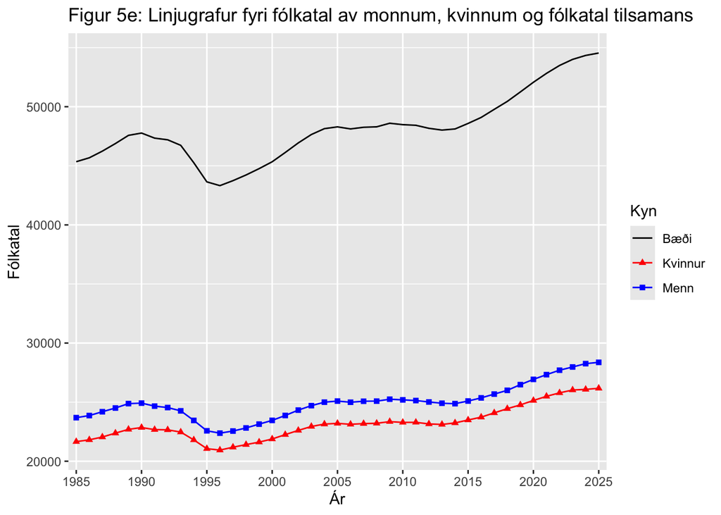

````markdown
```{r}
#| label: 5e
kyn_folkatal
# code here
ggplot(kyn_folkatal, aes(Ár, Fólkatal, colour = Kyn, shape = Kyn, group = Kyn)) +
  geom_line() +
  geom_point() +
  geom_line(data = arligt_folkatal, aes(Ár, Fólkatal, colour = "Bæði", shape = "Bæði", group = 1)) +
  scale_color_manual(values = c("Menn" = "blue", "Kvinnur" = "red", "Bæði" = "black")) +
  scale_x_discrete(breaks = seq(1985, 2025, by = 5)) +
  labs(title = "Figur 5e: Linjugrafur fyri fólkatal av monnum, kvinnum og fólkatal tilsamans")
```
````

> 5f1) `kyn_folkatal` has the columns `Ár, Kyn, Fólkatal`, while `arligt_folkatal` only has the columns `Ár, Fólkatal`. Pipe `arligt_folkatal` into the same structure as `kyn_folkatal`. Add a column `Kyn` with the value “Bæði”, reorder the columns, and bind it to `kyn_folkatal`. Save the output as `alt_folkatal` and display it. Check that it has the columns `Ár, Kyn, Fólkatal` with data types `int, chr, int`, respectively, and that the number of rows equals the number of rows in `kyn_folkatal` plus the number of rows in `arligt_folkatal`.

````markdown
```{r}
#| label: 5f1

# code here
alt_folkatal <- arligt_folkatal %>%
  mutate(Kyn = "Bæði") %>%
  select(Ár, Kyn, Fólkatal) %>%
  bind_rows(kyn_folkatal)
alt_folkatal <- alt_folkatal %>%
  mutate(Ár = as.integer(Ár))
alt_folkatal
```
````

```
# A tibble: 123 × 3
      Ár Kyn   Fólkatal
   <int> <chr>    <int>
 1  1985 Bæði     45346
 2  1986 Bæði     45677
 3  1987 Bæði     46241
 4  1988 Bæði     46883
 5  1989 Bæði     47576
 6  1990 Bæði     47771
 7  1991 Bæði     47342
 8  1992 Bæði     47200
 9  1993 Bæði     46733
10  1994 Bæði     45257
# ℹ 113 more rows
```

> 5f2) Simplify your plot code from 5e) by using only `alt_folkatal` as the data source to create a plot identical to the one in 5e).

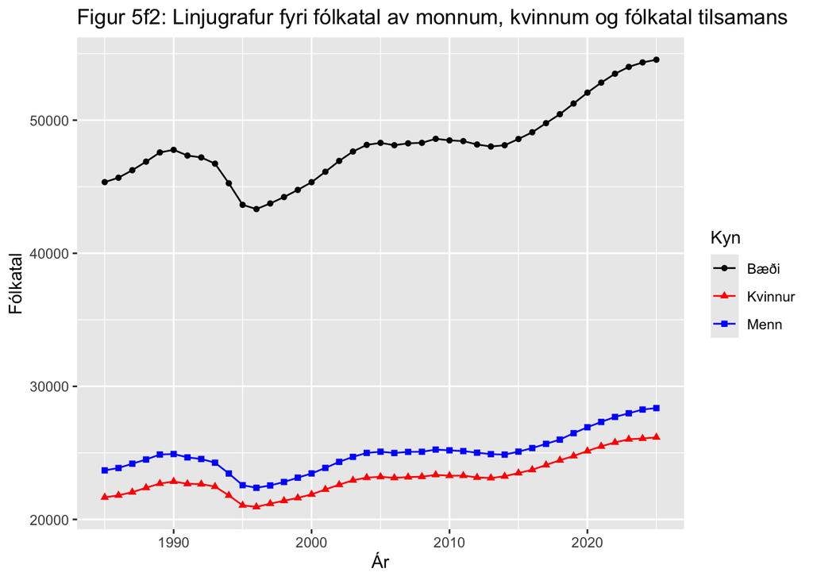

````markdown
```{r}
#| label: 5f2

# code here
ggplot(alt_folkatal, aes(Ár, Fólkatal, colour = Kyn, shape = Kyn, group = Kyn)) +
  geom_line() +
  geom_point() +
  scale_color_manual(values = c("Bæði" = "black", "Menn" = "blue", "Kvinnur" = "red")) +
  labs(title = "Figur 5f2: Linjugrafur fyri fólkatal av monnum, kvinnum og fólkatal tilsamans")
```
````

> 5f3) Now, we want to change the order of the legend text. Convert the `Kyn` column in `alt_folkatal` to a factor variable with levels “Bæði”, “Menn”, “Kvinnur”. Save the changes in an updated `alt_folkatal` and display it. Check that it now has the columns `Ár, Kyn, Fólkatal` with data types `int, fctr, int`, respectively.

````markdown
```{r}
#| label: 5f3

# code here
alt_folkatal <- alt_folkatal %>%
  mutate(Kyn = factor(Kyn, levels = c("Bæði", "Menn", "Kvinnur")))

alt_folkatal
```
````

```
# A tibble: 123 × 3
      Ár Kyn   Fólkatal
   <int> <fct>    <int>
 1  1985 Bæði     45346
 2  1986 Bæði     45677
 3  1987 Bæði     46241
 4  1988 Bæði     46883
 5  1989 Bæði     47576
 6  1990 Bæði     47771
 7  1991 Bæði     47342
 8  1992 Bæði     47200
 9  1993 Bæði     46733
10  1994 Bæði     45257
# ℹ 113 more rows
```

> 5f4) Run the exact same code as in 5f2) using the updated `alt_folkatal`. Note what changed as compared to the plot in 5f2)?

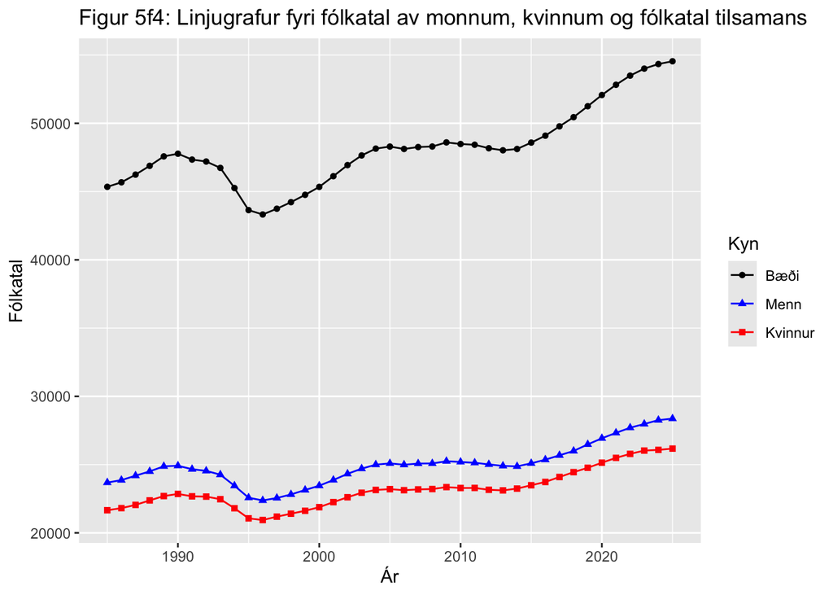

````markdown
```{r}
#| label: 5f4

# code here
ggplot(alt_folkatal, aes(Ár, Fólkatal, colour = Kyn, shape = Kyn, group = Kyn)) +
  geom_line() +
  geom_point() +
  scale_color_manual(values = c("Bæði" = "black", "Menn" = "blue", "Kvinnur" = "red")) +
  labs(title = "Figur 5f4: Linjugrafur fyri fólkatal av monnum, kvinnum og fólkatal tilsamans")
```
````

**TipText answer to 5f4**

The difference between 5f2 and 5f4 is that the order of the legend has changed. In 5f2 the order is “Bæði”, Kvinnur”, and “Menn”, and in 5f4 the order is “Bæði”, “Menn”, and “Kvinnur”. The shapes of the points have also changed. In 5f2 the “Menn” points are squares while the “Kvinnur” points are triangles. In 5f4 they are switched. The “Menn” points are triangles while the “Kvinnur” points are squares.